# 20_fractal_lines

## 20_fractal_lines

#### Question

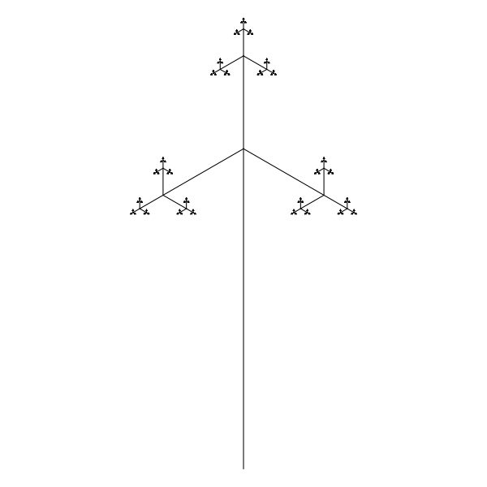

1. The fractal above is composed of many line segments. The largest segment is 1 unit long. There are then 3 segments, each with a length of $k = 0.29$. To continue the pattern, there are 9 segments with length $k^2=0.0841$. Then, 27 segments with length $k^3$ and 81 with length $k^4$ etc…

   How much total length is needed to construct this fractal (with infinite depths of recursion)? Find the sum of all the lengths.

   In other words, if $k=0.29$, evaluate the following:

   $$\sum_{i=0}^\infty(3k)^{i} ~=~ 1 + 3k + 9k^2 + 27k^3 + \ldots ~=~ ~?$$

   The tolerance is $\pm 0.01$.

#### Question

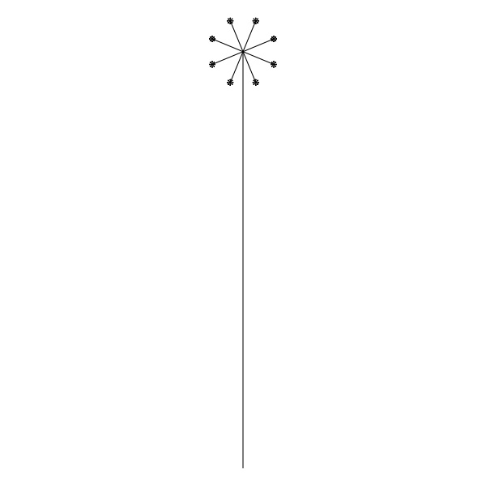

2. The fractal above is composed of many line segments. The largest segment is 1 unit long. There are then 8 segments, each with a length of $k = 0.08$. To continue the pattern, there are 64 segments with length $k^2=0.0064$. Then, 512 segments with length $k^3$ and 4096 with length $k^4$ etc…

   How much total length is needed to construct this fractal (with infinite depths of recursion)? Find the sum of all the lengths.

   In other words, if $k=0.08$, evaluate the following:

   $$\sum_{i=0}^\infty(8k)^{i} ~=~ 1 + 8k + 64k^2 + 512k^3 + \ldots ~=~ ~?$$

   The tolerance is $\pm 0.01$.

#### Question

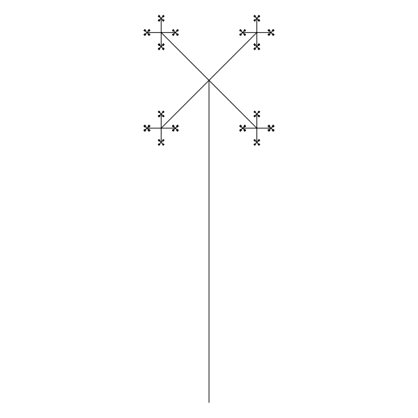

3. The fractal above is composed of many line segments. The largest segment is 1 unit long. There are then 4 segments, each with a length of $k = 0.21$. To continue the pattern, there are 16 segments with length $k^2=0.0441$. Then, 64 segments with length $k^3$ and 256 with length $k^4$ etc…

   How much total length is needed to construct this fractal (with infinite depths of recursion)? Find the sum of all the lengths.

   In other words, if $k=0.21$, evaluate the following:

   $$\sum_{i=0}^\infty(4k)^{i} ~=~ 1 + 4k + 16k^2 + 64k^3 + \ldots ~=~ ~?$$

   The tolerance is $\pm 0.01$.

#### Question

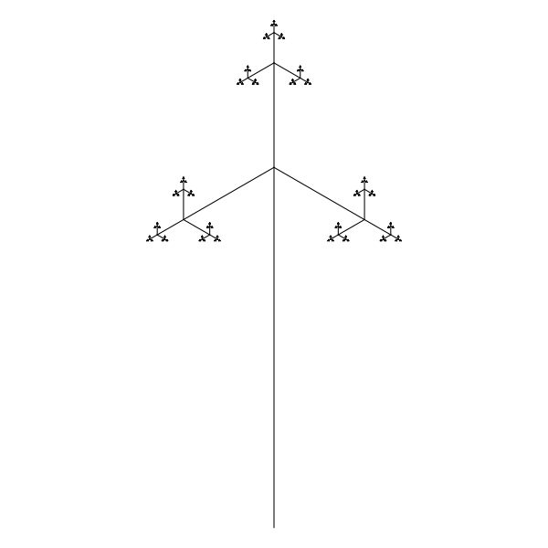

4. The fractal above is composed of many line segments. The largest segment is 1 unit long. There are then 3 segments, each with a length of $k = 0.29$. To continue the pattern, there are 9 segments with length $k^2=0.0841$. Then, 27 segments with length $k^3$ and 81 with length $k^4$ etc…

   How much total length is needed to construct this fractal (with infinite depths of recursion)? Find the sum of all the lengths.

   In other words, if $k=0.29$, evaluate the following:

   $$\sum_{i=0}^\infty(3k)^{i} ~=~ 1 + 3k + 9k^2 + 27k^3 + \ldots ~=~ ~?$$

   The tolerance is $\pm 0.01$.

#### Question

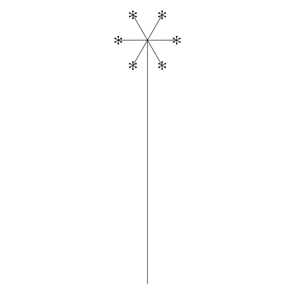

5. The fractal above is composed of many line segments. The largest segment is 1 unit long. There are then 6 segments, each with a length of $k = 0.12$. To continue the pattern, there are 36 segments with length $k^2=0.0144$. Then, 216 segments with length $k^3$ and 1296 with length $k^4$ etc…

   How much total length is needed to construct this fractal (with infinite depths of recursion)? Find the sum of all the lengths.

   In other words, if $k=0.12$, evaluate the following:

   $$\sum_{i=0}^\infty(6k)^{i} ~=~ 1 + 6k + 36k^2 + 216k^3 + \ldots ~=~ ~?$$

   The tolerance is $\pm 0.01$.

#### Question

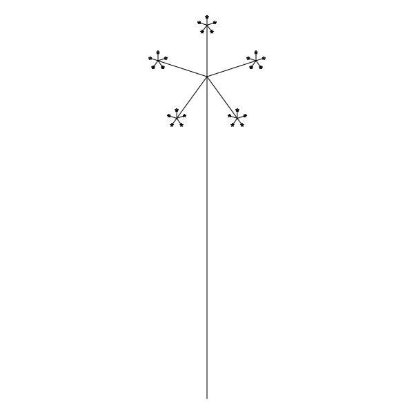

6. The fractal above is composed of many line segments. The largest segment is 1 unit long. There are then 5 segments, each with a length of $k = 0.16$. To continue the pattern, there are 25 segments with length $k^2=0.0256$. Then, 125 segments with length $k^3$ and 625 with length $k^4$ etc…

   How much total length is needed to construct this fractal (with infinite depths of recursion)? Find the sum of all the lengths.

   In other words, if $k=0.16$, evaluate the following:

   $$\sum_{i=0}^\infty(5k)^{i} ~=~ 1 + 5k + 25k^2 + 125k^3 + \ldots ~=~ ~?$$

   The tolerance is $\pm 0.01$.

#### Question

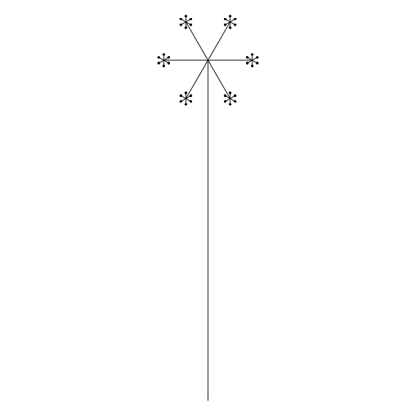

7. The fractal above is composed of many line segments. The largest segment is 1 unit long. There are then 6 segments, each with a length of $k = 0.13$. To continue the pattern, there are 36 segments with length $k^2=0.0169$. Then, 216 segments with length $k^3$ and 1296 with length $k^4$ etc…

   How much total length is needed to construct this fractal (with infinite depths of recursion)? Find the sum of all the lengths.

   In other words, if $k=0.13$, evaluate the following:

   $$\sum_{i=0}^\infty(6k)^{i} ~=~ 1 + 6k + 36k^2 + 216k^3 + \ldots ~=~ ~?$$

   The tolerance is $\pm 0.01$.

#### Question

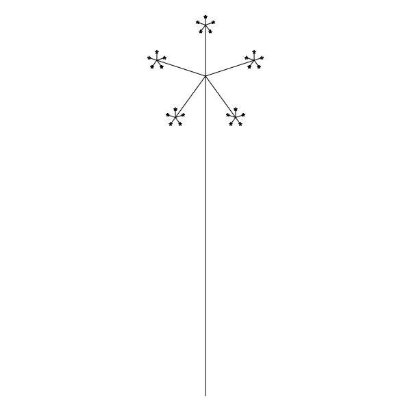

8. The fractal above is composed of many line segments. The largest segment is 1 unit long. There are then 5 segments, each with a length of $k = 0.16$. To continue the pattern, there are 25 segments with length $k^2=0.0256$. Then, 125 segments with length $k^3$ and 625 with length $k^4$ etc…

   How much total length is needed to construct this fractal (with infinite depths of recursion)? Find the sum of all the lengths.

   In other words, if $k=0.16$, evaluate the following:

   $$\sum_{i=0}^\infty(5k)^{i} ~=~ 1 + 5k + 25k^2 + 125k^3 + \ldots ~=~ ~?$$

   The tolerance is $\pm 0.01$.